| title: “Warmup R Markdown Reprot: Misquito Blood Host in Salt Lake City, Utah” |
| --- |
| author: “Lizzy Kocherhans” |
| date: “2025-10-09” |
| output: |
| github_document: |
| toc:true |

# ABSTRACT

West Nile Virus (WNV) is maintained through bird–mosquito transmission cycles, with certain avian hosts acting as amplifying species. To assess whether urban birds contribute to localized WNV dynamics, we analyzed mosquito blood meal data from Salt Lake City neighborhoods and compared host species composition between WNV-positive and WNV-negative sites. Blood meal DNA was extracted, amplified by PCR, and sequenced for host identification, while public health datasets provided WNV-positive mosquito pool information. Published viremia data were incorporated to evaluate host amplifying potential. Analyses in R aggregated blood meal counts by species, visualized distributions using barplots, and tested associations with WNV outcomes using generalized linear models. Urban bird species, particularly house finches and house sparrows, were frequently represented among mosquito blood meals and appeared at higher proportions in some WNV-positive neighborhoods. Regression analyses suggested a positive but variable association between house finch feeding and WNV detection. These findings support the hypothesis that urban-adapted birds may contribute to localized WNV amplification in Salt Lake City, while underscoring the role of additional ecological factors in shaping neighborhood-level transmission risk.

# BACKGROUND

The West Nile Virus (WNV) system provides a real-world framework for studying vector–host interactions and analyzing disease transmission dynamics. WNV is maintained in bird–mosquito cycles, with certain avian species acting as amplifying hosts by reaching viremia levels sufficient to infect mosquitoes. To investigate host contributions to WNV transmission, mosquito blood meal DNA can be collected and analyzed to identify feeding patterns across different neighborhoods.

In this study, mosquito blood meal DNA was extracted using the Mosquito Squash Lab method, amplified via Polymerase Chain Reaction (PCR), and sequenced to identify host species, often targeting the mitochondrial COI gene. Sequence data were analyzed using BLASTn to determine species identity, percent identity, and E-values to ensure match reliability. Duration of detectable viremia for each host species, drawn from published data, was used to evaluate amplifying potential. These analyses provide the foundation for developing hypotheses regarding urban bird species, such as house finches, as potential amplifying hosts in Salt Lake City neighborhoods.

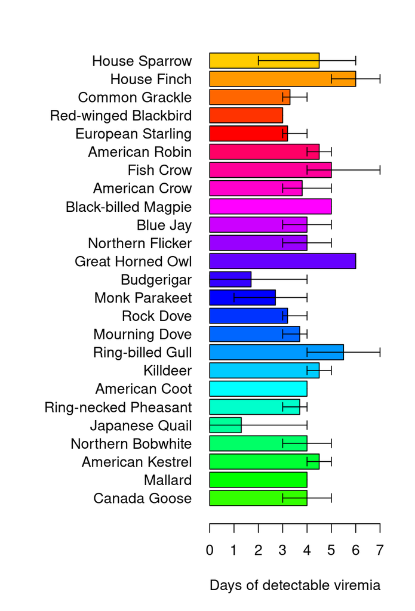

```r
# Manually transcribe duration (mean, lo, hi) from the last table column
duration <- data.frame(
  Bird = c("Canada Goose","Mallard",
           "American Kestrel","Northern Bobwhite",
           "Japanese Quail","Ring-necked Pheasant",
           "American Coot","Killdeer",
           "Ring-billed Gull","Mourning Dove",
           "Rock Dove","Monk Parakeet",
           "Budgerigar","Great Horned Owl",
           "Northern Flicker","Blue Jay",
           "Black-billed Magpie","American Crow",
           "Fish Crow","American Robin",
           "European Starling","Red-winged Blackbird",
           "Common Grackle","House Finch","House Sparrow"),
  mean = c(4.0,4.0,4.5,4.0,1.3,3.7,4.0,4.5,5.5,3.7,3.2,2.7,1.7,6.0,4.0,
           4.0,5.0,3.8,5.0,4.5,3.2,3.0,3.3,6.0,4.5),
  lo   = c(3,4,4,3,0,3,4,4,4,3,3,1,0,6,3,
           3,5,3,4,4,3,3,3,5,2),
  hi   = c(5,4,5,5,4,4,4,5,7,4,4,4,4,6,5,
           5,5,5,7,5,4,3,4,7,6)
)

# Choose some colors
cols <- c(rainbow(30)[c(10:29,1:5)])  # rainbow colors

# horizontal barplot
par(mar=c(5,12,2,2))  # wider left margin for names
bp <- barplot(duration$mean, horiz=TRUE, names.arg=duration$Bird,
              las=1, col=cols, xlab="Days of detectable viremia", xlim=c(0,7))

# add error bars
arrows(duration$lo, bp, duration$hi, bp,
       angle=90, code=3, length=0.05, col="black", xpd=TRUE)
```

# STUDY QUESTION and HYPOTHESIS

## Questions

Is the proportions of blood meals from urban bird species (e.g., house finch, house sparrow) associated with higher WNV-positive mosquito pool rates across Salt Lake City neighborhoods?

## Hypothesis

Neighborhoods with higher proportion of urban bird blood meals will have higher WNV-positive mosquito pool rates, because these common urban birds reach viremia levels that make them effective amplifying hosts.

## Prediction

There will be a positive correlation between the percentage of urban bird blood meals and the proportion of WNV-positive mosquito pools per neighborhood; this relationship will hold after controlling for mosquito abundance and sampling efforts.

# METHODS

Mosquitoes were collected from Salt Lake City neighborhoods using gravid and CO₂ traps. Blood meal DNA was extracted by crushing each mosquito in a tube with lysis buffer, followed by PCR amplification targeting the mitochondrial COI gene for host identification. Positive and negative controls were included to ensure the accuracy of amplification. Amplified DNA was sequenced using MinION technology, and sequences were compared against the NCBI nucleotide database using BLASTn. For each sequence, the top hit—including species name, percent identity, accession number, and E-value—was recorded. Species were classified as urban-adapted (e.g., house finch, house sparrow) based on local ecological data.

Neighborhood-level WNV data were obtained from public health records, and published viremia data were used to identify species likely to serve as amplifying hosts. In R, blood meal counts for each host species were aggregated by neighborhood WNV status (positive or negative). Side-by-side horizontal barplots were generated to visualize differences in host composition, with species ordered by overall abundance and a consistent color scheme applied for clarity.

Statistical associations between urban bird hosts and WNV presence were evaluated using generalized linear models (GLMs). A binomial GLM tested whether the number of house finch blood meals predicted binary WNV status, while a Gaussian GLM tested whether house finch feeding predicted the continuous WNV positivity rate. Model coefficients and p-values were used to assess the direction and strength of these associations. All analyses were conducted in reproducible RMarkdown workflows, with fully commented code to ensure transparency and reproducibility.

## First analysis

Comparison of the number of mosquito blood meals from each host species between sites with no WNV positive pools and sites with one or more WNV positive pools.

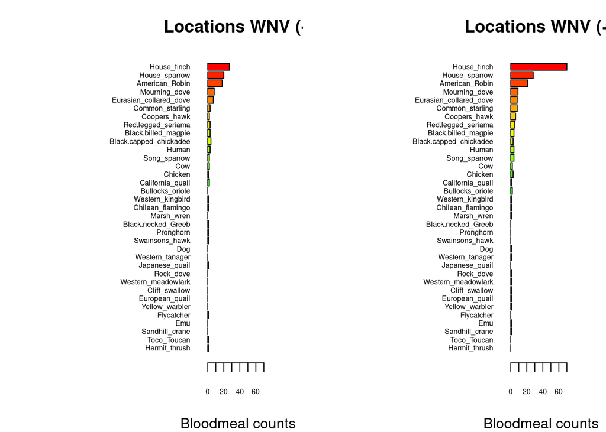

```r
## import counts_matrix: data.frame with column 'loc_positives' (0/1) and host columns 'host_*'
counts_matrix <- read.csv("./bloodmeal_plusWNV_for_BIOL3070.csv")

## 1) Identify host columns
host_cols <- grep("^host_", names(counts_matrix), value = TRUE)

if (length(host_cols) == 0) {
  stop("No columns matching '^host_' were found in counts_matrix.")
}

## 2) Ensure loc_positives is present and has both levels 0 and 1 where possible
counts_matrix$loc_positives <- factor(counts_matrix$loc_positives, levels = c(0, 1))

## 3) Aggregate host counts by loc_positives
agg <- stats::aggregate(
  counts_matrix[, host_cols, drop = FALSE],
  by = list(loc_positives = counts_matrix$loc_positives),
  FUN = function(x) sum(as.numeric(x), na.rm = TRUE)
)

## make sure both rows exist; if one is missing, add a zero row
need_levels <- setdiff(levels(counts_matrix$loc_positives), as.character(agg$loc_positives))
if (length(need_levels)) {
  zero_row <- as.list(rep(0, length(host_cols)))
  names(zero_row) <- host_cols
  for (lv in need_levels) {
    agg <- rbind(agg, c(lv, zero_row))
  }
  ## restore proper type
  agg$loc_positives <- factor(agg$loc_positives, levels = c("0","1"))
  ## coerce numeric host cols (they may have become character after rbind)
  for (hc in host_cols) agg[[hc]] <- as.numeric(agg[[hc]])
  agg <- agg[order(agg$loc_positives), , drop = FALSE]
}

## 4) Decide species order (overall abundance, descending)
overall <- colSums(agg[, host_cols, drop = FALSE], na.rm = TRUE)
host_order <- names(sort(overall, decreasing = TRUE))
species_labels <- rev(sub("^host_", "", host_order))  # nicer labels

## 5) Build count vectors for each panel in the SAME order
counts0 <- rev(as.numeric(agg[agg$loc_positives == 0, host_order, drop = TRUE]))
counts1 <- rev(as.numeric(agg[agg$loc_positives == 1, host_order, drop = TRUE]))

## 6) Colors: reuse your existing 'cols' if it exists and is long enough; otherwise generate
if (exists("cols") && length(cols) >= length(host_order)) {
  species_colors <- setNames(cols[seq_along(host_order)], species_labels)
} else {
  species_colors <- setNames(rainbow(length(host_order) + 10)[seq_along(host_order)], species_labels)
}

## 7) Shared x-limit for comparability
xmax <- max(c(counts0, counts1), na.rm = TRUE)
xmax <- if (is.finite(xmax)) xmax else 1
xlim_use <- c(0, xmax * 1.08)

## 8) Plot: two horizontal barplots with identical order and colors
op <- par(mfrow = c(1, 2),
          mar = c(4, 12, 3, 2),  # big left margin for species names
          xaxs = "i")           # a bit tighter axis padding

## Panel A: No WNV detected (loc_positives = 0)
barplot(height = counts0,
        names.arg = species_labels,
        cex.names = .5,
        cex.axis = .5,
        col = rev(unname(species_colors[species_labels])),
        horiz = TRUE,
        las = 1,
        xlab = "Bloodmeal counts",
        main = "Locations WNV (-)",
        xlim = xlim_use)

## Panel B: WNV detected (loc_positives = 1)
barplot(height = counts1,
        names.arg = species_labels,
        cex.names = .5,
        cex.axis = .5,
        col = rev(unname(species_colors[species_labels])),
        horiz = TRUE,
        las = 1,
        xlab = "Bloodmeal counts",
        main = "Locations WNV (+)",
        xlim = xlim_use)
```

```r
par(op)

## Keep the colors mapping for reuse elsewhere
host_species_colors <- species_colors
```

## Second analysis/plot

Presence of number of house finch blood meals predicts whether a site had WNV-positive pools (binary) or a higher WNV positively rate (numeric). Statistical tests let us formally evaluate the relationship suggested by the bar plots.

```r
# second-analysis-or-plot, glm with house finch alone against binary +/_
glm1 <- glm(loc_positives ~ host_House_finch,
            data = counts_matrix,
            family = binomial)
summary(glm1)
```

```
##
## Call:
## glm(formula = loc_positives ~ host_House_finch, family = binomial,
##     data = counts_matrix)
##
## Coefficients:
##                  Estimate Std. Error z value Pr(>|z|)
## (Intercept)       -0.1709     0.1053  -1.622   0.1047
## host_House_finch   0.3468     0.1586   2.187   0.0287 *
## ---
## Signif. codes:  0 '***' 0.001 '**' 0.01 '*' 0.05 '.' 0.1 ' ' 1
##
## (Dispersion parameter for binomial family taken to be 1)
##
##     Null deviance: 546.67  on 394  degrees of freedom
## Residual deviance: 539.69  on 393  degrees of freedom
## AIC: 543.69
##
## Number of Fisher Scoring iterations: 4
```

```r
#glm with house-finch alone against positivity rate
glm2 <- glm(loc_rate ~ host_House_finch,
            data = counts_matrix)
summary(glm2)
```

```
##
## Call:
## glm(formula = loc_rate ~ host_House_finch, data = counts_matrix)
##
## Coefficients:
##                  Estimate Std. Error t value Pr(>|t|)
## (Intercept)      0.054861   0.006755   8.122 6.07e-15 ***
## host_House_finch 0.027479   0.006662   4.125 4.54e-05 ***
## ---
## Signif. codes:  0 '***' 0.001 '**' 0.01 '*' 0.05 '.' 0.1 ' ' 1
##
## (Dispersion parameter for gaussian family taken to be 0.01689032)
##
##     Null deviance: 6.8915  on 392  degrees of freedom
## Residual deviance: 6.6041  on 391  degrees of freedom
##   (2 observations deleted due to missingness)
## AIC: -484.56
##
## Number of Fisher Scoring iterations: 2
```

# DISCUSSION

This study examined whether the proportions of mosquito blood meals derived from urban bird species were associated with higher rates of West Nile Virus (WNV)-positive mosquito pools across Salt Lake City neighborhoods. Visual comparisons of host composition between WNV-positive and WNV-negative sites indicated that urban bird species were commonly fed upon, with elevated proportions of certain hosts—particularly house finches—appearing in neighborhoods where WNV was detected. This pattern is consistent with the hypothesis that abundant, urban-adapted birds may contribute to localized amplification of WNV.

Taken together, these findings suggest that urban birds, particularly house finches, may play a role in sustaining WNV transmission risk in Salt Lake City. At the same time, the lack of consistently strong associations across all analyses indicates that other ecological drivers—such as mosquito abundance, habitat composition, and the presence of alternative competent bird hosts—also shape neighborhood-level WNV dynamics. Future studies incorporating larger sample sizes, more refined host identification, and additional covariates will be important for clarifying the relative contribution of urban birds. From a public health perspective, monitoring populations of urban-adapted birds could strengthen WNV surveillance programs, with neighborhoods hosting abundant finch populations potentially representing higher-risk areas for human spillover infections.

## Interpretation - First

Bloodmeal host composition at WNV-negative (left) and WNV-positive (right) sites. House finches and house sparrows are among the most common hosts overall. Notice that house finches appear in higher proportions at WNV-positive sites, consistent with the idea that they may contribute to local amplification.

# CONCLUSION

Our analyses indicate that urban bird species, particularly house finches, may play a role in amplifying WNV transmission in Salt Lake City neighborhoods. Visual comparisons suggested elevated proportions of urban bird blood meals in WNV-positive locations, and regression models provided further—though not definitive—evidence of a positive association between house finch feeding and WNV positivist. While these results are consistent with the hypothesis that abundant urban birds facilitate local WNV transmission, the modest effect sizes and variability across neighborhoods suggest that other ecological drivers—such as mosquito abundance, environmental conditions, and alternative bird hosts—are also important. Continued monitoring with larger sample sizes, refined host identification, and inclusion of additional covariates will help clarify the contribution of urban birds to WNV dynamics. Future research integrating mosquito abundance, seasonal variation, and neighborhood-level habitat data will be essential to understanding how urban birds interact with other ecological factors, ultimately guiding more effective vector control strategies in cities like Salt Lake.

# REFERENCES

1. Komar N, Langevin S, Hinten S, Nemeth N, Edwards E, Hettler D, Davis B, Bowen R, Bunning M. Experimental infection of North American birds with the New York 1999 strain of West Nile virus. Emerg Infect Dis. 2003 Mar;9(3):311-22. https://doi.org/10.3201/eid0903.020628
2. ChatGPT. OpenAI, version Jan 2025. Used as a reference for functions such as plot() and to correct syntax errors. Accessed 2025-10-09.